# CNN Lab 6

## Business Understanding

### Overview

We will be using a collection of images of dogs, sorted by breed, as our dataset for this lab. The dataset can be found at footnote 1; it was created by Stanford graduate students and their advisor as a data set specifically for fine-grained image categorization. Besides the categorized pictures of dogs, the data set also includes bounding box annotations for each of the images, class labels, and information on how the creators used the set to train and test. The full set contains 20,560 images, with 120 different breeds of dogs represented. There are at least 148 images of each breed, with the Maltese dog having the most images at 252. Each picture is at least 200 pixels by 200 pixels in size, with most pictures generally not being much larger than that.

### Purpose

This data is a specifically created set of images, created using images found on ImageNet under the 'Canis familiaris' node. The three graduate students, Khosla, Jayadevaprakash, and Yao, along with their mentor, Fei-Fei, created this set of images specifically with the purpose of creating a dataset for fine-grained image categorization. They went through the images found on ImageNet one breed at a time, being sure to select images that were only classified under one node, and removed images which had distortion, major occlusion, and other defects, in order to create a subset of images that they believed addressed the drawbacks of other fine-grained image categorization datasets. Further information about their process and their results in achieving their dataset goals can be found at footnote 2.

### Prediction Task

The prediction task for this dataset is relatively simple: to be able to recognize the breed of a dog from a picture, which may be of different age, color, shape than the original images, or which may be partially occluded. Generally, there is little inter-class variation in the appearance of dogs <sup>[[1]](#footnote1)</sup> and large intra-class variation<sup>[[1]](#footnote1)</sup>, making recognizing dogs a tough challenge for categorization. Even with a human, there are certain types of dogs that pose challenges when it comes to differentiation, especially among mixed breed dogs; to be able to identify the type of dog in an image mechanically would help in cases as simple as a person trying to identify what breeds are in a mongrel's ancestry.  
At a more advanced level, it would be helpful to many photo sharing websites to be able to recognize a type of dog from the image posted, in order to create more tailored advertising for said person. To be able to recognize a dog is to be able to advertise generalized dog products at a user, while to be able to recognize breed is to be able to target a user for very specific dog-related purchases, which may drive higher advertising revenue. It has been demonstrated how much more effective targeted ads can be than their non-targeted counterparts<sup>[[3]](#footnote3)</sup>; to continue to truly personalize ads based on the very specifics of a person's lifestyle is the ultimate goal of web advertisment. Advertising is what drives the modern web, and the modern dog owner spends \$1549<sup>[[4]](#footnote4)</sup> per year on dog-related purchases, to be able to further target advertising has the potential to be very valuable. There is likely no specific level of accuracy required for such use, as long as the classifier is somewhat accurate. Generally, customers simply ignore ads that do not relate to them<sup>[[11]](#footnote11)</sup>, so while there is an opportunity cost to not having a perfectly accurate classifier, there is likely to be no material cost. Even with just the ability to tell between a small dog and a big dog, advertising can be more focused; the increase in accuracy is nonessential, but useful nonetheless.  
Besides helping those mentioned above, the ability to identify dogs is one that has major implications to veterinarians and others in industries working directly with dogs. When it comes to caring for dogs, there are material differences between certain breeds. Different breeds vary in their needs, including requiring different nutrition<sup>[[5]](#footnote5)</sup> and different levels of exercise<sup>[[6]](#footnote6)</sup>; most important, however, is dosage of veterinary drugs. There are certain drugs used by vets that are important to the health of a dog, but have the potential to be deadly to certain breeds which carry specific gene mutations<sup>[[7]](#footnote7)</sup>. To be able to identify a dog, and avoid using a drug that could have fatal side effects is invaluable. With a mechanical method of dog identification, vets can be more certain that they are treating a dog the correct way for its genetics, and are advising the owners of the correct way to feed and take care of it on a regular basis. Just like doctors in other fields, it is unlikely that veterinary physicians would use a computer as an infallible resource, rather they would use it to assist and support in the diagnostics they already practice<sup>[[12]](#footnote12)</sup>. Due to such usage, where it is unlikely that egregious errors will ever make it through the process, the level of accuracy required would depend on the amount of time the classifier takes. If the vet were to spend a significant amount of time using the classifier, and consistently got results that were incorrect, it is unlikely that the classifier would see any use. Ideally the classifier would hit 90% accuracy, the level of accuracy found in DNA dog tests<sup>[[13]](#footnote13)</sup>, but users would likely accept lower accuracy in general for reasons of convenience.  
Another field in which being able to identify a dog is important is pet adoption and animal shelters. One in ten dogs adopted from shelters in the United States are returned within six months, most often due to unexpected costs or behaviors<sup>[[8]](#footnote8)</sup>. Many adopt dogs not knowing the dog's exact genetic makeup, and are unaware of what the dog will grow into from the puppy they adopt. While it is impossible to fully predict a dog's size and behavior simply from its ancestry, the ancestry is still one of the best indicators of what a dog will be like as an adult. To be able to tell what kind of dog a puppy will become can assist in the operations of pet shelters and other adoption organiztions, giving them the ability to inform the customer what they can expect in the future from any given dog. When it comes to the accuracy of shelters identifying dog breeds, most are not very reliable. Only 12.5% of dogs identified by shelters match with the shelter-described breeds exactly<sup>[[14]](#footnote14)</sup>, so any accuracy above 12.% is an improvement. However, one must take into account how egregious the errors of the shelters were; the degree of error may matter more than the incidence of error.  
Finally, it can be important to identify dogs in order to know that one is receiving the actual type of dog that they are told they are receiving. Only two states currently offer statutory recourse for the misrepresentation of a breed in purchasing a dog: Florida and Minnesota<sup>[[9]](#footnote9)</sup>. In other states, it is possible to attempt recourse through various other methods, such as breach of contract, but it is not always guaranteed that the customer can be assured that they will receive exactly what they wanted. With a method of identifying dogs that does not rely on human trust, customers can feel more confident in their purchases of dogs, knowing that they are almost certainly purchasing the correct merchandise. The accuracy of a classifier is not as vital in such cases, due to the rarity of the situation, and the avenues of recourse already in place. If a customer is already distrustful enough of a business to use such a system, it is likely that they are simply looking for something to assist them in confirming their suspicions; at the point of purchase, not much is on the line for either side of the transaction. Again, if the classifier could outdo DNA classification, and improve over 90% accuracy, it would be ideal, and perhaps become the new standard of verifying pedigree, but for the most part in such scenarios it would likely serve as a method to help the customer overcome any cognative dissonance.

### Third Parties

The third parties that would be interested in such a classification system would be a combination of social media sites and advertisers. Working in unison, they would be able to look at the pictures posted on the social media account of a user, and not only determine what kind of pet they have, they could go further and determine the subtype of that pet, in order to maximize personalization of the ads. The most obvious example of a site that would use a system such as this one would be Instagram. Instagram is entirely based around lifestyle and images, and pet photos are very common. In the past, Instagram has been cited as a model that may have a difficult time monetizing, so to be able to further increase the probability of someone clicking on an advertisment is very valuable. Similar rationales exist with Facebook, Twitter, even Snapchat (albeit somewhat ethically fuzzier with Snap). Overall, any site that relies on user-generated content and advertising would likely reap the benefits of being able to classify pets as granularly as possible.  
Besides the third parties in technology, anyone in the fields of veterinary medicine and dog breeding, or even just those that love dogs, could use the app to help in the pursuit of those things. Whether it is ensuring that the medicine being given is appropriate, confirming that a dog is what it is being said, or just trying to identify a cute dog seen in one's neighborhood, the ability to identify or confirm the human identification of a dog is a valuable resource. In the United States, 36.5% of households own dogs<sup>[[10]](#footnote10)</sup>; it is the largest pet market in the country. From owning dogs, to selling dogs, to treating dogs, the identification of dogs runs through American life; lending a helping hand through technology could touch millions of lives, helping both the humans and their dogs.

### Cited

1: http://vision.stanford.edu/aditya86/ImageNetDogs/  
2: http://people.csail.mit.edu/khosla/papers/fgvc2011.pdf  
3: https://hbr.org/2016/04/targeted-ads-dont-just-make-you-more-likely-to-buy-they-can-change-how-you-think-about-yourself  
4: http://www.americanpetproducts.org/press_industrytrends.asp  
5: https://www.petmd.com/blogs/nutritionnuggets/jcoates/2012/feb/nutrition_differences_for_small_toy_large_breeds-12459  
6: https://thebark.com/content/how-much-exercise-does-your-dog-need  
7: https://www.petmd.com/blogs/fullyvetted/2013/jan/toxic-ivermectin-and-safe-use-of-ivermectin-29671  
8: https://www.americanhumane.org/app/uploads/2016/08/petsmart-keeping-pets-phase-ii.pdf  
9: https://www.avma.org/Advocacy/StateAndLocal/Pages/pet-lemon-laws.aspx  
10: https://www.avma.org/KB/Resources/Statistics/Pages/Market-research-statistics-US-pet-ownership.aspx  
11: http://adage.com/article/cmo-strategy/consumers-ignore-ads-telling-stories/125529/  
12: https://www.ncbi.nlm.nih.gov/pmc/articles/PMC4029126/  
13: http://news.vin.com/vinnews.aspx?articleId=23206  
14: https://www.ncbi.nlm.nih.gov/pubmed/20183478

## Evaluation Criteria:

We will use accuracy to evalueate our model. Although accuracy is not usually the best metric, accuracy will suffice in giving us an accurate depiction of how our specific model performs. Our team was exploring whether or not to focus on Sensitivity or Recall, but decided that given the charachteristics of our dataset and our classification problem, accuracy would be a better measure.

The reasons for this selection are as follows:

### Classification Problem:

Our model aims to loabel dog images with the breed of dog in the photo. It is a large multi-class problem and a fairly complex task. The use cases for this model stem from the areas of pet health, pet adoption/sales, and pet image labeling. Of these use cases, pet health has highest cost for misclassification, then adoption/sales, and then image labeling.

With the health use case, we would like to have both recall and precision. Recall in our case (using corgis as an example) means that we can identifiy as many corgis correctly. Precision means that when we label something as a corgi, there is a good chance to beleive that this image is a corgi. The health case needs both precision and recall, because the ways we can fail (not giving a dog the proper care) is either mistreating a dog (confusing breed) or not recognizing the breed of the dog and then not treating it. To have both of these, we must have both percision and recall.

The dog sale/adoption use case is very similar. The biggest cost in this case is posting an incorrect "advertisement". This can come with legal risks and business risks. So in this case what is most important is precision. There is a case to be made that recall is also very important (opportunity costs), but those do not become customer facing issues so recall is not as important as precision in this case.

With the final use case, object recognition, the dogs will generally be labeled in photos and the like. Mislabeling the breed does not have a large cost, as these systems will not be in crucial locations, so generall recall/precision will be important.

Given all of these classification problems, it is apparant that both recall and precision are important. Thus we would use a metric that incorporates both, and that would be accuracy.

### Dataset:

Given that we would like to use accuracy, we have to first make sure our dataset is balanced class wise. Given that there are over 20,000 images and the largest class has around 200 images, there is no large dominant class. This means that accuracy will still be a very informative metric in our tests.

### Evaluation Metrics:

We will use accuracy as our main evaluation metric. We will explore precision and recall when need be, although we beleive accuracy does well enough to contain both of those metrics.

# Train Test Split:

We will use a 10-fold stratified cross validation for our training and testing. We chose this cross-validation method given the nature of our data set and how our model will be used in practice. The 10-fold aspect of this method allows us to test the performance amongst many test sets so we get an accurate sense of generalization performance.

### Data Set:

A defining charachteristic of our dataset is the large multi-class aspect of it. There are many labels to predict with no real dominant dataset (200 max out of 20,000). This led us to want to stratify our set, so we are able to train on every class. There are generally the same amount of photos by class so we would like to keep that relationship. This is also because our performance metric is accuracy, and large class imbalance can change the validatiy of that metric. Keeping the class relationships constant will help with giving accuracy better meaning as a performance metric.

### Usage:

The usage of this model in practice will be trained over a large corpus of dogs. This is because in practice no body knows which breeds will be predicted, there is a wide range of possible breeds. Thus, in practice the users will create a large set that they will use to train the model. This set can grow as more breeds are added into the dataset.

Furthermore, There is no distinction between old photos or new photos, just any photos of that breed. Once a set can recognize a breed well, the images of that set will be solidified. A stratified strategy mimics the idea that we are training on a huge corpus (same ratio of pictures) and allows for a large hollistic training. It keeps the ratios the same accross the tests to keep is standard for our generalization testing.

### Conclusion:

Thus, we will use 10-fold cross validation to test our data. It is important to know that for this lab, given the large training time and size of our dataset, we were only able to run each model for one fold. This compromises t-tests, but we see that the outputs of the models are different enough that it is possible to see the general relative performance of the models.

```python
#Imports
import scipy
import numpy as np
import pandas as pd
import matplotlib.pyplot as plt
from skimage import data, color
from skimage.transform import rescale, resize, downscale_local_mean
import os
import os.path
import random


#Set the image size and path to the data
img_size = (75,100,3)
img_path = '../Images/'
#img_path = '/home/tylergiallanza/Downloads/Images'
img_paths = []
img_annotations = []

#The images are stored in subdirectories - go through all of them
for dirpath, dirnames, filenames in os.walk(img_path):
    for filename in [f for f in filenames if f.endswith(".jpg")]:
        img_paths.append(os.path.join(dirpath, filename))
        img_annotations.append(dirpath.split('/')[-1].split('-')[1])
img_annotations = img_annotations[0:4000]
```

```python
import pickle

img_data = []
paths = ['../img_data'+str(i) for i in range(6)]
for path in paths:
    img = pickle.load(open(path,'rb'))
    img_data.extend(img)
```

```python
%%time
img_data = []
X_mlp=[]
for path in img_paths[0:4000]:
    X_mlp.append((resize(plt.imread(path).astype(np.uint8),img_size)).flatten())
    img_data.append((resize(plt.imread(path).astype(np.uint8),img_size)))#.flatten())
X_mlp = np.array(X_mlp)
```

```python
img_data = img_data[:4000]
print(len(img_data))
```

```
4000
```

```python
print(len(img_annotations))
```

```
4000
```

```python
from sklearn.model_selection import StratifiedKFold
from sklearn.preprocessing import OneHotEncoder
from copy import deepcopy

skf = StratifiedKFold(n_splits = 10)

X = np.array(img_data)

unique_classes = list(set(img_annotations))
class_dict = {unique_classes[x]:x for x in range(len(unique_classes))}
reverse_class_dict = {x:unique_classes[x] for x in range(len(unique_classes))}
y = np.array([class_dict[i] for i in img_annotations])

train_list = []
test_list = []

for train_index, test_index in skf.split(X, y):
    train_list.append(train_index)
    test_list.append(test_index)



X_train = deepcopy(X[train_list[0]])
X_test = deepcopy(X[test_list[0]])
y_train = deepcopy(y[train_list[0]])
y_test = deepcopy(y[test_list[0]])
'''
X_train_mlp = deepcopy(X_mlp[train_list[0]])
X_test_mlp = deepcopy(X_mlp[test_list[0]])
y_train_mlp = deepcopy(y[train_list[0]])
y_test_mlp = deepcopy(y[test_list[0]])
'''
NUM_CLASSES = len(unique_classes)

input_size= img_size[0]*img_size[1] if len(img_size)==2 else img_size[0]*img_size[1]*img_size[2]
```

```python
X_train.shape,X_test.shape
```

[output not shown]

```
Chihuahua
```

[figure not shown]

```
Rhodesian_ridgeback
```

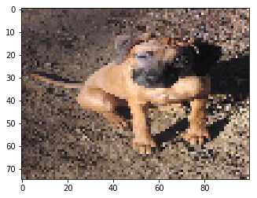

```
Ibizan_hound
```

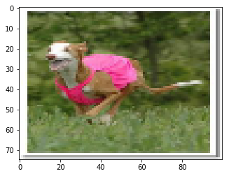

```python
print(reverse_class_dict[y_train[100]])
plt.imshow(X_train[120].reshape(img_size),cmap='gray')
plt.show()
print(reverse_class_dict[y_train[1450]])
plt.imshow(X_train[1450].reshape(img_size),cmap='gray')
plt.show()
print(reverse_class_dict[y_train[3499]])
plt.imshow(X_train[3499].reshape(img_size),cmap='gray')
plt.show()
```

```python
from sklearn import metrics as mt
from matplotlib import pyplot as plt
import seaborn as sns
%matplotlib inline

def compare_mlp_cnn(cnn, mlp, X_test, y_test):
    plt.figure(figsize=(15,5))
    if cnn is not None:
        yhat_cnn = np.argmax(cnn.predict(np.expand_dims(X_test, axis=1)), axis=1)
        acc_cnn = mt.accuracy_score(y_test,yhat_cnn)
        plt.subplot(1,2,1)
        cm = mt.confusion_matrix(y_test,yhat_cnn)
        cm = cm/np.sum(cm,axis=1)[:,np.newaxis]
        sns.heatmap(cm, annot=True, fmt='.2f')
        plt.title('CNN: '+str(acc_cnn))

    if mlp is not None:
        yhat_mlp = np.argmax(mlp.predict(X_test_mlp), axis=1)
        acc_mlp = mt.accuracy_score(y_test_mlp,yhat_mlp)
        plt.subplot(1,2,2)
        cm = mt.confusion_matrix(y_test_mlp,yhat_mlp)
        cm = cm/np.sum(cm,axis=1)[:,np.newaxis]
        sns.heatmap(cm,annot=True, fmt='.2f')
        plt.title('MLP: '+str(acc_mlp))
```

```python
from collections import Counter
print(Counter(y))
print(class_dict)
```

```
Counter({21: 252, 14: 239, 18: 218, 9: 214, 1: 196, 15: 195, 17: 188, 10: 187, 20: 187, 5: 185, 11: 182, 7: 175, 0: 172, 8: 172, 13: 171, 2: 159, 16: 155, 12: 153, 4: 152, 19: 151, 3: 149, 6: 148})
{'Rhodesian_ridgeback': 0, 'Italian_greyhound': 11, 'Japanese_spaniel': 5, 'Walker_hound': 12, 'bluetick': 13, 'papillon': 1, 'Afghan_hound': 14, 'black': 2, 'Pekinese': 3, 'Chihuahua': 4, 'beagle': 15, 'Ibizan_hound': 16, 'redbone': 6, 'Blenheim_spaniel': 17, 'basset': 7, 'Irish_wolfhound': 18, 'to…
```

# Modeling

#### Note: We used confusion matricies instead of ROC curves because of the high multi-class nature of the problem. Although we could use micro or macro averageing, we beleived it to be a better visualization and more meaningful to use Confusion Matricies (so we could visualize for exaple when a model was choosing the majority class only). This is only increased by the fact that we have at least 21 classes for each model that we tested.

## MLP

```python
import keras
from keras.models import Sequential
from keras.layers import Reshape
from keras.layers import Dense, Dropout, Activation, Flatten
from keras.layers import Conv2D, MaxPooling2D

keras.__version__
```

```
'2.1.5'
```

```python
%%time
y_train_ohe_mlp = keras.utils.to_categorical(y_train_mlp, NUM_CLASSES)
y_test_ohe_mlp = keras.utils.to_categorical(y_test_mlp, NUM_CLASSES)

# make a 3 layer keras MLP
mlp = Sequential()
mlp.add( Dense(input_dim=X_train_mlp.shape[1], units=30, activation='relu') )
mlp.add( Dense(units=15, activation='relu') )
mlp.add( Dense(NUM_CLASSES) )
mlp.add( Activation('softmax') )

mlp.compile(loss='categorical_crossentropy',
              optimizer='rmsprop',
              metrics=['accuracy'])

history_mlp = mlp.fit(X_train_mlp, y_train_ohe_mlp,
        validation_data=(X_test_mlp,y_test_ohe_mlp),
        batch_size=64, epochs=10,
        shuffle=True, verbose=1)
```

```
Train on 3589 samples, validate on 411 samples
CPU times: user 43.9 s, sys: 40.9 s, total: 1min 24s
Wall time: 18.6 s
```

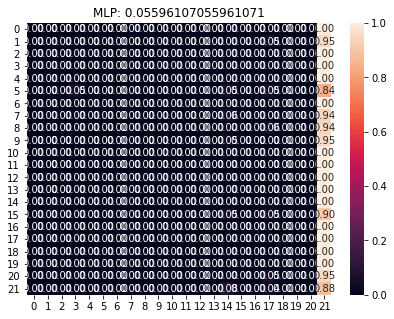

```python
compare_mlp_cnn(None,mlp,X_test,y_test)
```

```python
print(history_mlp.history)
```

```
{'loss': [3.562566314775919, 3.2340613362781845, 3.136448383729881, 3.128006464659786, 3.085418494307719, 3.1292284641069235, 3.102395110955375, 3.095294426928393, 3.1191297947247736, 3.0840898553917886], 'val_acc': [0.043795620437956206, 0.06082725060827251, 0.06326034063260341, 0.06326034063260341…
```

```
Text(0.5,0,'epochs')
```

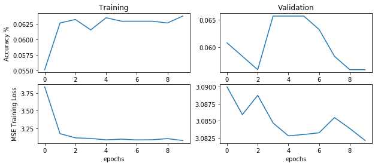

```python
from matplotlib import pyplot as plt

%matplotlib inline
plt.figure(figsize=(10,4))
plt.subplot(2,2,1)
plt.plot(history_mlp.history['acc'])

plt.ylabel('Accuracy %')
plt.title('Training')
plt.subplot(2,2,2)
plt.plot(history_mlp.history['val_acc'])
plt.title('Validation')

plt.subplot(2,2,3)
plt.plot(history_mlp.history['loss'])
plt.ylabel('MSE Training Loss')
plt.xlabel('epochs')

plt.subplot(2,2,4)
plt.plot(history_mlp.history['val_loss'])
plt.xlabel('epochs')
```

### MLP Evaluation:

Our MLP model does not do too well when it comes to both the training and test set. We see an accuracy ranging from 5.5% to 6.25%. This is not a very high percent, but there is an understandable reason for why the model is returning what it is.

The problem is a large multi-class problem and the images are not good enough at allowing the model to learn quickly. Our geuss is that this MLP is not deep enough or good enough at generalization to create meaningful seperations between all the calsses. We estimate that the model will benefit from added layers and potentially some convolutional layers that will make it easier to understand the differences between classes.

#### Main Weakness:

We see that the model is guessing class 21 for almost all of the cases (The most frequent class, Maltese Dog). This further illustrates that the model may not be complex enough to truly undestand the differences between classes.

## AlexNet

For this section we will use AlexNet. The model is comprised of multiple convolutional layers, max pooling, and a couple dense layers. We chose to use ReLu as our activation function for this model to keep the dradients as large as possible. Our final activation is a softmax. We estimate that this model should give better performance given that the model can handle dimensionality reduction better than a standard MLP with its convolutional layers.

```python
# import os
import numpy as np
import pandas as pd
import matplotlib.pyplot as plt
from random import shuffle
import pickle, datetime

import keras
from keras.datasets import cifar10
from keras.models import Model, Sequential
from keras.layers import Input, Dense, Dropout, Flatten, Activation, Reshape
from keras.layers import Conv2D, Convolution2D, MaxPooling2D
from keras.layers.convolutional import ZeroPadding2D
from keras.layers.normalization import BatchNormalization
from keras.utils import np_utils
from keras import optimizers
from keras.preprocessing import sequence
from keras.preprocessing.image import ImageDataGenerator, array_to_img, img_to_array, load_img

import  PIL.Image
```

```python
#adapted from http://dandxy89.github.io/ImageModels/alexnet/
DROPOUT = 0.5
input_layer = Input(shape = (75, 100, 3))
# First convolutional Layer (96x11x11)
x = Conv2D(filters = 96, kernel_size = (11,11), strides = (4,4), activation = "relu")(input_layer)
x = MaxPooling2D(pool_size = (3,3), strides=(2,2), data_format='channels_last')(x)
x = BatchNormalization()(x)

# Second convolutional Layer (256x5x5)
x = ZeroPadding2D(padding = (2,2))(x)
x = Convolution2D(filters = 256, kernel_size = (5,5), strides = (1,1), activation = "relu")(x)
x = MaxPooling2D(pool_size = (3,3), strides=(2,2))(x)
x = BatchNormalization()(x)

# Rest 3 convolutional layers
x = ZeroPadding2D(padding = (1,1))(x)
x = Convolution2D(filters = 384, kernel_size = (3,3), strides = (1,1), activation = "relu")(x)

x = ZeroPadding2D(padding = (1,1))(x)
x = Convolution2D(filters = 384, kernel_size = (3,3), strides = (1,1), activation = "relu")(x)

x = ZeroPadding2D(padding = (1,1))(x)
x = Convolution2D(filters = 256, kernel_size = (3,3), strides = (1,1), activation = "relu")(x)

x = MaxPooling2D(pool_size = (3,3), strides=(2,2))(x)
x = Flatten()(x)

x = Dense(4096, activation="relu")(x)
x = Dropout(DROPOUT)(x)

x = Dense(4096, activation="relu")(x)
x = Dropout(DROPOUT)(x)

final_dim = NUM_CLASSES
final_act = "softmax"
output_layer = Dense(final_dim, activation=final_act)(x)

model = Model(input_layer, output_layer)
model.summary()
```

```
_________________________________________________________________
Layer (type)                 Output Shape              Param #
=================================================================
input_2 (InputLayer)         (None, 75, 100, 3)        0
_________________________________________________________________
conv2d_6 (Conv2D)            (None, 17, 23, 96)        34944
_________________________________________________________________
max_pooling2d_4 (MaxPooling2 (None, 8, 11, 96)         0
_________________________________________________________________
batch_normalization_3 (Batch (None, 8, 11, 96)         384
_________________________________________________________________
zero_padding2d_5 (ZeroPaddin (None, 12, 15, 96)        0
_________________________________________________________________
conv2d_7 (Conv2D)            (None, 8, 11, 256)        614656
_________________________________________________________________
max_pooling2d_5 (MaxPooling2 (None, 3, 5, 256)         0
_________________________________________________________________
batch_normalization_4 (Batch (None, 3, 5, 256)         1024
_________________________________________________________________
zero_padding2d_6 (ZeroPaddin (None, 5, 7, 256)         0
_________________________________________________________________
conv2d_8 (Conv2D)            (None, 3, 5, 384)         885120
_________________________________________________________________
zero_padding2d_7 (ZeroPaddin (None, 5, 7, 384)         0
_________________________________________________________________
conv2d_9 (Conv2D)            (None, 3, 5, 384)         1327488
_________________________________________________________________
zero_padding2d_8 (ZeroPaddin (None, 5, 7, 384)         0
_________________________________________________________________
conv2d_10 (Conv2D)           (None, 3, 5, 256)         884992
_________________________________________________________________
max_pooling2d_6 (MaxPooling2 (None, 1, 2, 256)         0
_________________________________________________________________
flatten_2 (Flatten)          (None, 512)               0
_________________________________________________________________
dense_7 (Dense)              (None, 4096)              2101248
_________________________________________________________________
dropout_3 (Dropout)          (None, 4096)              0
_________________________________________________________________
dense_8 (Dense)              (None, 4096)              16781312
_________________________________________________________________
dropout_4 (Dropout)          (None, 4096)              0
_________________________________________________________________
dense_9 (Dense)              (None, 22)                90134
=================================================================
Total params: 22,721,302
Trainable params: 22,720,598
Non-trainable params: 704
_________________________________________________________________
```

```python
%%time
from keras.callbacks import EarlyStopping

model.compile(optimizer='adam',
                  loss='categorical_crossentropy',
                    metrics=['accuracy'])
model.load_weights('initial_weights_alex_net.h5')
#model.save_weights('initial_weights_alex_net.h5')
y_train_ohe = keras.utils.to_categorical(y_train, NUM_CLASSES)
y_test_ohe = keras.utils.to_categorical(y_test, NUM_CLASSES)
print(X_train.shape, y_train_ohe.shape)
history_cnn1= model.fit(X_train, y_train_ohe,
        batch_size=32,
        epochs=20,
        shuffle=True,
        validation_data=(X_test,y_test_ohe),
       # callbacks=[EarlyStopping(monitor='val_acc')],
        verbose=1)
model.save_weights('final_weights_alex_net.h5')
```

```
(3589, 75, 100, 3) (3589, 22)
Train on 3589 samples, validate on 411 samples
CPU times: user 2h 32min 41s, sys: 1h 36min 31s, total: 4h 9min 12s
Wall time: 12min 32s
```

```python
scores = model.evaluate(X_test, y_test_ohe, verbose=1)
```

```python
scores
```

```
[3.133991587771116, 0.165450121708885]
```

```
Text(0.5,0,'epochs')
```

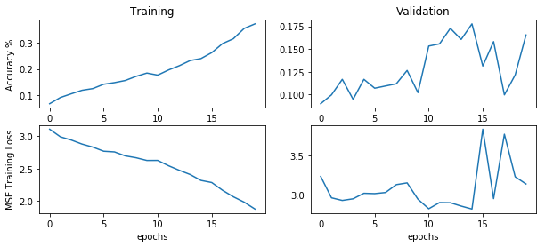

```python
from matplotlib import pyplot as plt

%matplotlib inline
plt.figure(figsize=(10,4))
plt.subplot(2,2,1)
plt.plot(history_cnn1.history['acc'])

plt.ylabel('Accuracy %')
plt.title('Training')
plt.subplot(2,2,2)
plt.plot(history_cnn1.history['val_acc'])
plt.title('Validation')

plt.subplot(2,2,3)
plt.plot(history_cnn1.history['loss'])
plt.ylabel('MSE Training Loss')
plt.xlabel('epochs')

plt.subplot(2,2,4)
plt.plot(history_cnn1.history['val_loss'])
plt.xlabel('epochs')
```

```python
from sklearn import metrics as mt
from matplotlib import pyplot as plt
from skimage.io import imshow
import seaborn as sns
%matplotlib inline

def summarize_net(net, X_test, y_test, title_text=''):
    plt.figure(figsize=(15,5))
    yhat = np.argmax(net.predict(X_test), axis=1)
    acc = mt.accuracy_score(y_test,yhat)
    cm = mt.confusion_matrix(y_test,yhat)
    cm = cm/np.sum(cm,axis=1)[:,np.newaxis]
    sns.heatmap(cm, annot=True, fmt='.2f')
    plt.title(title_text+'{:.4f}'.format(acc))
```

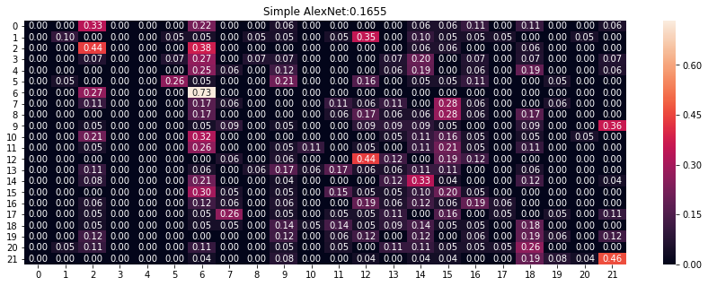

```python
summarize_net(model, X_test, y_test, title_text='Simple AlexNet:')
```

## AlexNet Evaluation

#### Suggestions:

Given the Training, Validation, and loss graphs, we think it may be useful to run this model for more epochs. It seems that in the validation the model had just potentially beaten out a local optimum at the end. Therefore, if we had more time we would look into increasing the number of epochs and see how performance is changed due to that.

## BabyResNet

We estimate that with the new purturbed data and the higher number of convolutional layers, this model will be able to perform batter as it learns more about generalization.

```python
X_train = deepcopy(X[train_list[0]])
X_test = deepcopy(X[test_list[0]])
y_train = deepcopy(y[train_list[0]])
y_test = deepcopy(y[test_list[0]])

import keras.utils
y_train_ohe = keras.utils.to_categorical(y_train, NUM_CLASSES)
y_test_ohe = keras.utils.to_categorical(y_test, NUM_CLASSES)

X_train_reshaped = X_train.reshape((-1,100,75,3))
X_test_reshaped = X_test.reshape((-1,100,75,3))
```

## Data Expansion:

To augment our data we will apply the following transformations: 5 degree roation and horizontal/vertical shift. We feel that this will be a good addition to our training set because the images in the dataset and in practice will not have any standard format to them. Each picture of each dog is very different and very much a normal day to day photo. Purturbing the data will help the model focus on the features unique to each class as opposed to specific information about eachimage.

We estimate that this new data expansion will help with the generalization performance of our models.

```python
from keras.preprocessing.image import ImageDataGenerator

datagen = ImageDataGenerator(featurewise_center=False,
    samplewise_center=False,
    featurewise_std_normalization=False,
    samplewise_std_normalization=False,
    zca_whitening=False,
    rotation_range=5,
    width_shift_range=0.1,
    height_shift_range=0.1,
    shear_range=0.,
    zoom_range=0.,
    channel_shift_range=0.,
    fill_mode='nearest',
    cval=0.,
    horizontal_flip=False,
    vertical_flip=False,
    rescale=None,
    data_format='channels_last')

datagen.fit(X_train_reshaped)
```

```python
print(X_train_reshaped.shape,y_train.shape)
print(X_test_reshaped.shape,y_test.shape)
```

```
(3587, 100, 75, 3) (3587,)
(413, 100, 75, 3) (413,)
```

```python
from keras.layers import average, concatenate, Add
from keras.models import Input, Model
from keras.regularizers import l2

resnet_layers = [(64,False),(64,False),(64,False),(128,True)]
l2_lambda = .000001
sh = (100,75,3)

inputs = Input(shape=sh)

x = Conv2D(filters=64,
              input_shape=sh,
              kernel_size=(7,7),
              strides=(2,2),
              kernel_initializer='he_uniform',
              kernel_regularizer=l2(l2_lambda),
              padding='same',
              activation='relu',
              data_format='channels_last')(inputs)
x = MaxPooling2D(pool_size=(2,2), data_format='channels_last')(x)

for num_filters, stride in resnet_layers:
    x_split = x
    if stride:
        x = Conv2D(filters=num_filters,
                  input_shape=sh,
                  kernel_size=(3,3),
                  strides=(2,2),
                  kernel_initializer='he_uniform',
                  kernel_regularizer=l2(l2_lambda),
                  padding='same',
                  activation='relu',
                  data_format='channels_last')(x_split)
    else:
        x = Conv2D(filters=num_filters,
                  input_shape=sh,
                  kernel_size=(3,3),
                  kernel_initializer='he_uniform',
                  kernel_regularizer=l2(l2_lambda),
                  padding='same',
                  activation='relu',
                  data_format='channels_last')(x_split)
    x = Conv2D(filters=num_filters,
              input_shape=sh,
              kernel_size=(3,3),
              kernel_initializer='he_uniform',
              kernel_regularizer=l2(l2_lambda),
              padding='same',
              activation='relu',
              data_format='channels_last')(x)

    if stride:
        x_split = Conv2D(filters=num_filters,
                  input_shape=sh,
                  kernel_size=(1,1),
                  strides=(2,2),
                  kernel_initializer='he_uniform',
                  kernel_regularizer=l2(l2_lambda),
                  padding='same',
                  activation='relu',
                  data_format='channels_last')(x_split)
    x = Add()([x,x_split])
    x = Activation('relu')(x)

x = Flatten()(x)
x = Dropout(0.25)(x)
x = Dense(512)(x)
x = Activation('relu')(x)
x = Dropout(0.5)(x)
x = Dense(NUM_CLASSES)(x)
x = Activation('softmax')(x)

baby_resnet = Model(inputs=inputs,outputs=x)

baby_resnet.summary()
```

```
__________________________________________________________________________________________________
Layer (type)                    Output Shape         Param #     Connected to
==================================================================================================
input_3 (InputLayer)            (None, 100, 75, 3)   0
__________________________________________________________________________________________________
conv2d_11 (Conv2D)              (None, 50, 38, 64)   9472        input_3[0][0]
__________________________________________________________________________________________________
max_pooling2d_2 (MaxPooling2D)  (None, 25, 19, 64)   0           conv2d_11[0][0]
__________________________________________________________________________________________________
conv2d_12 (Conv2D)              (None, 25, 19, 64)   36928       max_pooling2d_2[0][0]
__________________________________________________________________________________________________
conv2d_13 (Conv2D)              (None, 25, 19, 64)   36928       conv2d_12[0][0]
__________________________________________________________________________________________________
add_5 (Add)                     (None, 25, 19, 64)   0           conv2d_13[0][0]
                                                                 max_pooling2d_2[0][0]
__________________________________________________________________________________________________
activation_7 (Activation)       (None, 25, 19, 64)   0           add_5[0][0]
__________________________________________________________________________________________________
conv2d_14 (Conv2D)              (None, 25, 19, 64)   36928       activation_7[0][0]
__________________________________________________________________________________________________
conv2d_15 (Conv2D)              (None, 25, 19, 64)   36928       conv2d_14[0][0]
__________________________________________________________________________________________________
add_6 (Add)                     (None, 25, 19, 64)   0           conv2d_15[0][0]
                                                                 activation_7[0][0]
__________________________________________________________________________________________________
activation_8 (Activation)       (None, 25, 19, 64)   0           add_6[0][0]
__________________________________________________________________________________________________
conv2d_16 (Conv2D)              (None, 25, 19, 64)   36928       activation_8[0][0]
__________________________________________________________________________________________________
conv2d_17 (Conv2D)              (None, 25, 19, 64)   36928       conv2d_16[0][0]
__________________________________________________________________________________________________
add_7 (Add)                     (None, 25, 19, 64)   0           conv2d_17[0][0]
                                                                 activation_8[0][0]
__________________________________________________________________________________________________
activation_9 (Activation)       (None, 25, 19, 64)   0           add_7[0][0]
__________________________________________________________________________________________________
conv2d_18 (Conv2D)              (None, 13, 10, 128)  73856       activation_9[0][0]
__________________________________________________________________________________________________
conv2d_19 (Conv2D)              (None, 13, 10, 128)  147584      conv2d_18[0][0]
__________________________________________________________________________________________________
```

[output cut: 10 more lines]

```
__________________________________________________________________________________________________
dense_3 (Dense)                 (None, 512)          8520192     dropout_3[0][0]
__________________________________________________________________________________________________
activation_11 (Activation)      (None, 512)          0           dense_3[0][0]
__________________________________________________________________________________________________
dropout_4 (Dropout)             (None, 512)          0           activation_11[0][0]
__________________________________________________________________________________________________
dense_4 (Dense)                 (None, 24)           12312       dropout_4[0][0]
__________________________________________________________________________________________________
activation_12 (Activation)      (None, 24)           0           dense_4[0][0]
==================================================================================================
Total params: 8,993,304
Trainable params: 8,993,304
Non-trainable params: 0
__________________________________________________________________________________________________
```

```python
%%time

from keras.callbacks import EarlyStopping
# Let's train the model
baby_resnet.compile(loss='categorical_crossentropy',
              optimizer='adam',
              metrics=['accuracy'])


# we need to exapnd the dimensions here to give the
#   "channels" dimension expected by Keras
'''
#resnet.fit(np.expand_dims(X_train, axis=1), y_train_ohe,
resnet.fit(X_train_reshaped, y_train_ohe,
        batch_size=32, epochs=10,
        shuffle=True, verbose=1,
       validation_data=(np.expand_dims(X_test,axis=1),y_test_ohe))
'''
history_babyres = baby_resnet.fit_generator(datagen.flow(X_train_reshaped,y_train_ohe,batch_size=32),
                    steps_per_epoch=int(len(X_train_reshaped)/32),
                    epochs=20,verbose=1,
                    validation_data=(X_test_reshaped,y_test_ohe),
                    callbacks=[EarlyStopping(monitor='val_loss',patience=5)])

baby_resnet.save_weights('final_weights_baby_res.h5')
```

```
CPU times: user 2h 39min 35s, sys: 2h 20min 16s, total: 4h 59min 51s
Wall time: 11min 45s
```

```
Text(0.5,0,'epochs')
```

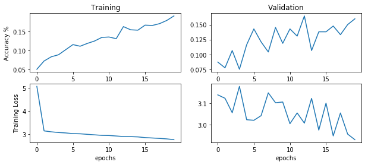

```python
from matplotlib import pyplot as plt

%matplotlib inline
plt.figure(figsize=(10,4))
plt.subplot(2,2,1)
plt.plot(history_babyres.history['acc'])

plt.ylabel('Accuracy %')
plt.title('Training')
plt.subplot(2,2,2)
plt.plot(history_babyres.history['val_acc'])
plt.title('Validation')

plt.subplot(2,2,3)
plt.plot(history_babyres.history['loss'])
plt.ylabel('Training Loss')
plt.xlabel('epochs')

plt.subplot(2,2,4)
plt.plot(history_babyres.history['val_loss'])
plt.xlabel('epochs')
```

```python
from sklearn import metrics as mt
from matplotlib import pyplot as plt
import seaborn as sns
%matplotlib inline

def summarize_net(net, X_test, y_test, title_text=''):
    plt.figure(figsize=(15,5))
    yhat = np.argmax(net.predict(X_test), axis=1)
    acc = mt.accuracy_score(y_test,yhat)
    cm = mt.confusion_matrix(y_test,yhat)
    cm = cm/np.sum(cm,axis=1)[:,np.newaxis]
    sns.heatmap(cm, annot=True, fmt='.2f')
    plt.title(title_text+'{:.4f}'.format(acc))
```

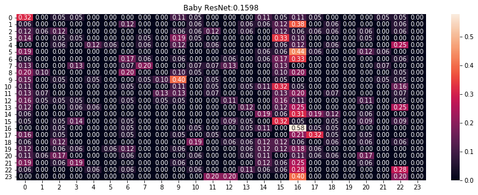

```python
summarize_net(baby_resnet, X_test_reshaped, y_test, title_text='Baby ResNet:')
```

## Baby ResNet Evaluation:

The confusion matrix is not dominated by one class, so that is a good indicator, and it also shows that potentially the added data helps with the generalization performance of the model.

#### Comparison to MLP and AlexNet:

The model does far better than MLP, 2-3x better. The model however is only slightly worse in performance than AlexNet. The numbers of the two models are too close hoever for us to definitively say which model is the batter model. Given the low n value we have we cannot perform a meaningful t-test and thus cannot difinitively say which is better. We would need to train more of these models to evaluate that.

#### Sugesstions:

Given the Graphs above, we beleive it would be worthwhile to let the model continue for more epochs. Both the training and validation accuracy are increasing. We had to cut it off to be able to run the model well, but a next step would be to let the model run for more epocjs until it reached a plateau in validation accuracy.

## ResNet34 (Simple Baby ResNet)

```python
from keras.layers import average, concatenate, Add
from keras.models import Input, Model
from keras.regularizers import l2
from keras.layers import Conv2D, MaxPooling2D, AveragePooling2D

resnet_layers = [(64,False),(64,False),(64,False),
                 (128,True),(128,False),(128,False),(128,False),
                (256,True),(256,False),(256,False),(256,False),(256,False),(256,False),
                (512,True),(512,False),(512,False)]
l2_lambda = .000001
sh = (100,75,3)

inputs = Input(shape=sh)

x = Conv2D(filters=64,
              input_shape=sh,
              kernel_size=(7,7),
              strides=(2,2),
              kernel_initializer='he_uniform',
              kernel_regularizer=l2(l2_lambda),
              padding='same',
              activation='relu',
              data_format='channels_last')(inputs)
x = MaxPooling2D(pool_size=(2,2),strides=(2,2), data_format='channels_last')(x)

for num_filters, stride in resnet_layers:
    x_split = x
    if stride:
        x = Conv2D(filters=num_filters,
                  input_shape=sh,
                  kernel_size=(3,3),
                  strides=(2,2),
                  kernel_initializer='he_uniform',
                  kernel_regularizer=l2(l2_lambda),
                  padding='same',
                  activation='relu',
                  data_format='channels_last')(x_split)
    else:
        x = Conv2D(filters=num_filters,
                  input_shape=sh,
                  kernel_size=(3,3),
                  kernel_initializer='he_uniform',
                  kernel_regularizer=l2(l2_lambda),
                  padding='same',
                  activation='relu',
                  data_format='channels_last')(x_split)
    x = Conv2D(filters=num_filters,
              input_shape=sh,
              kernel_size=(3,3),
              kernel_initializer='he_uniform',
              kernel_regularizer=l2(l2_lambda),
              padding='same',
              activation='relu',
              data_format='channels_last')(x)

    if stride:
        x_split = Conv2D(filters=num_filters,
                  input_shape=sh,
                  kernel_size=(1,1),
                  strides=(2,2),
                  kernel_initializer='he_uniform',
                  kernel_regularizer=l2(l2_lambda),
                  padding='same',
                  activation='relu',
                  data_format='channels_last')(x_split)
    x = Add()([x,x_split])
    x = Activation('relu')(x)
    #if pooling:
        #x = MaxPooling2D(pool_size=(2,2), data_format='channels_last')(x)
x = AveragePooling2D(pool_size=(2,2), data_format='channels_last')(x)

#Add more layers

x = Flatten()(x)
x = Dropout(0.25)(x)
x = Dense(1000)(x)
x = Activation('relu')(x)
x = Dropout(0.5)(x)
x = Dense(NUM_CLASSES)(x)
x = Activation('softmax')(x)

resnet34 = Model(inputs=inputs,outputs=x)

resnet34.summary()
```

```
__________________________________________________________________________________________________
Layer (type)                    Output Shape         Param #     Connected to
==================================================================================================
input_5 (InputLayer)            (None, 100, 75, 3)   0
__________________________________________________________________________________________________
conv2d_57 (Conv2D)              (None, 50, 38, 64)   9472        input_5[0][0]
__________________________________________________________________________________________________
max_pooling2d_4 (MaxPooling2D)  (None, 25, 19, 64)   0           conv2d_57[0][0]
__________________________________________________________________________________________________
conv2d_58 (Conv2D)              (None, 25, 19, 64)   36928       max_pooling2d_4[0][0]
__________________________________________________________________________________________________
conv2d_59 (Conv2D)              (None, 25, 19, 64)   36928       conv2d_58[0][0]
__________________________________________________________________________________________________
add_25 (Add)                    (None, 25, 19, 64)   0           conv2d_59[0][0]
                                                                 max_pooling2d_4[0][0]
__________________________________________________________________________________________________
activation_29 (Activation)      (None, 25, 19, 64)   0           add_25[0][0]
__________________________________________________________________________________________________
conv2d_60 (Conv2D)              (None, 25, 19, 64)   36928       activation_29[0][0]
__________________________________________________________________________________________________
conv2d_61 (Conv2D)              (None, 25, 19, 64)   36928       conv2d_60[0][0]
__________________________________________________________________________________________________
add_26 (Add)                    (None, 25, 19, 64)   0           conv2d_61[0][0]
                                                                 activation_29[0][0]
__________________________________________________________________________________________________
activation_30 (Activation)      (None, 25, 19, 64)   0           add_26[0][0]
__________________________________________________________________________________________________
conv2d_62 (Conv2D)              (None, 25, 19, 64)   36928       activation_30[0][0]
__________________________________________________________________________________________________
conv2d_63 (Conv2D)              (None, 25, 19, 64)   36928       conv2d_62[0][0]
__________________________________________________________________________________________________
add_27 (Add)                    (None, 25, 19, 64)   0           conv2d_63[0][0]
                                                                 activation_30[0][0]
__________________________________________________________________________________________________
activation_31 (Activation)      (None, 25, 19, 64)   0           add_27[0][0]
__________________________________________________________________________________________________
conv2d_64 (Conv2D)              (None, 13, 10, 128)  73856       activation_31[0][0]
__________________________________________________________________________________________________
conv2d_65 (Conv2D)              (None, 13, 10, 128)  147584      conv2d_64[0][0]
__________________________________________________________________________________________________
```

[output cut: 124 more lines]

```
__________________________________________________________________________________________________
dense_5 (Dense)                 (None, 1000)         1025000     dropout_5[0][0]
__________________________________________________________________________________________________
activation_45 (Activation)      (None, 1000)         0           dense_5[0][0]
__________________________________________________________________________________________________
dropout_6 (Dropout)             (None, 1000)         0           activation_45[0][0]
__________________________________________________________________________________________________
dense_6 (Dense)                 (None, 24)           24024       dropout_6[0][0]
__________________________________________________________________________________________________
activation_46 (Activation)      (None, 24)           0           dense_6[0][0]
==================================================================================================
Total params: 22,325,184
Trainable params: 22,325,184
Non-trainable params: 0
__________________________________________________________________________________________________
```

```python
%%time

from keras.callbacks import EarlyStopping
# Let's train the model

resnet34.compile(loss='categorical_crossentropy',
              optimizer='adam',
              metrics=['accuracy'])

history_res34 = resnet34.fit_generator(datagen.flow(X_train_reshaped,y_train_ohe,batch_size=32),
                    steps_per_epoch=int(len(X_train_reshaped)/32),
                    epochs=20,verbose=1,
                    validation_data=(X_test_reshaped,y_test_ohe),
                    callbacks=[EarlyStopping(monitor='val_loss',patience=5)])

resnet34.save_weights('final_weights_res_34.h5')
```

```
CPU times: user 9h 33min 35s, sys: 4h 50min 10s, total: 14h 23min 45s
Wall time: 33min 42s
```

```
Text(0.5,0,'epochs')
```

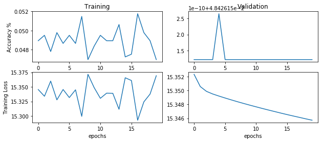

```python
plt.figure(figsize=(10,4))
plt.subplot(2,2,1)
plt.plot(history_res34.history['acc'])

plt.ylabel('Accuracy %')
plt.title('Training')
plt.subplot(2,2,2)
plt.plot(history_res34.history['val_acc'])
plt.title('Validation')

plt.subplot(2,2,3)
plt.plot(history_res34.history['loss'])
plt.ylabel('Training Loss')
plt.xlabel('epochs')

plt.subplot(2,2,4)
plt.plot(history_res34.history['val_loss'])
plt.xlabel('epochs')
```

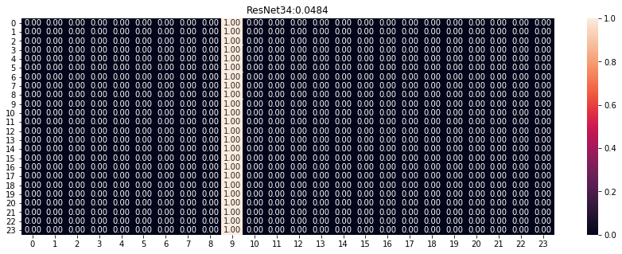

```python
summarize_net(resnet34, X_test_reshaped, y_test, title_text='ResNet34:')
```